# Variance of Assumption-Making

Julian Frattini

2026-04-09

This document analyses the variance of responses to the question “If you are in a situation where you lack information and have to make an assumption to proceed in your project, what do you typically do?” (`v_455`) across demographic factors. The variable has the following levels:

| Level | Text |
| --- | --- |
| Reasonable assumption | Make a reasonable assumption myself and proceed. |
| Ask customer | Ask the customer, end user, or both what should be assumed before proceeding. |
| Don’t know | I do not know. |
| Not applicable | Does not apply. |

```r
v <- "v_455"
vname <- "assumption-making"
labels <- c("Reasonable assumption", "Ask customer", "Don't know", "Not applicable")
levels <- c("Make a reasonable assumption myself and proceed.",
            "Ask the customer, end user, or both what should be assumed before proceeding.",
            "I do not know.", "Does not apply.")

# minimum likelihood of responses to be considered "common"
level.common <- 0.2
```

## Variables

We consider the following demographic factors:

| Code | Name | Question | Type |
| --- | --- | --- | --- |
| `v_23` | country | In which country are you personally located? | categorical |
| `v_3` | size | How many people are involved in your project? | numeric |
| `v_457` | way of working | How would you personally characterise the way your project works? | ordinal |
| `v_1` | sector | Please select the main industrial sector of your project or the application domain of the software you build. | categorical |
| `v_16` | external | Does your project involve external partners? | binary |
| `v_357` | distributed | Is your project distributed? | binary |
| `v_377` | virtualization | Do you tend to work from home, on-site, or both? | ordinal |
| `v_17` | role | What is the main role you occupy in your project? | categorical |

## Data Analysis

We analyze the variance of the response variable following established practices of Bayesian data analysis.[^1]

```r
d <- load_data(run = "2024", data_path = "../../data", file = "runs/napire2024/data_cleaned_2024.csv") %>%
  select("lfdn", # respondent identifier
    "v_3", "Country", "v_1", "v_457", "v_16", "v_357", "v_377", "v_17", # demographic factors
    v) %>%  # response variable
  drop_na() %>%
  mutate(
    response = factor(!!sym(v), levels = levels, labels = labels, ordered = FALSE)
  )
str(d)
```

```
## 'data.frame':    338 obs. of  11 variables:
##  $ lfdn    : int  100 102 104 106 108 109 110 111 115 117 ...
##  $ v_3     : int  20 5 8 20 25 25 9 7 20 6 ...
##  $ Country : chr  "Germany" "Sweden" "Germany" "Sweden" ...
##  $ v_1     : Factor w/ 22 levels "Agriculture",..: 5 2 6 12 6 15 2 2 10 17 ...
##  $ v_457   : Ord.factor w/ 6 levels "Agile"<"Rather agile"<..: 5 1 3 2 1 4 2 5 1 4 ...
##  $ v_16    : Factor w/ 3 levels "Yes","No","I don't know": 1 2 1 2 1 1 2 2 1 2 ...
##  $ v_357   : logi  TRUE FALSE TRUE FALSE TRUE TRUE ...
##  $ v_377   : Ord.factor w/ 6 levels "Almost completely on-site"<..: 3 1 3 2 1 5 2 3 4 3 ...
##  $ v_17    : Factor w/ 12 levels "Business Analyst",..: 12 3 4 11 5 8 3 4 1 3 ...
##  $ v_455   : Factor w/ 4 levels "Make a reasonable assumption myself and proceed.",..: 1 3 2 2 2 2 2 1 2 1 ...
##  $ response: Factor w/ 4 levels "Reasonable assumption",..: 1 3 2 2 2 2 2 1 2 1 ...
```

For each outcome variable, we train one Bayesian regression model on all demographic variables as predictors.

### Modelling

First, we define a formula regressing the outcome variable of interest on the demographic factors

```r
f <- bf(response ~ 1 + v_3 + Country + v_1 + v_457 + v_16 + v_357 + v_377 + v_17)

#get_prior(f, data = d, family = categorical(link = logit))
```

For each coefficient implied by a predictor, we specify a prior based on domain knowledge.

```r
p <- c(
  set_prior("normal(0, 1)", class = "Intercept", dpar = c("muAskcustomer", "muDontknow", "muNotapplicable")),
  set_prior("normal(0, 0.2)", class = "b", dpar = c("muAskcustomer", "muDontknow", "muNotapplicable"))
)
```

Since the response variable is a categorical variable without any inherent ordering to it, we use a categorical model family to model it.

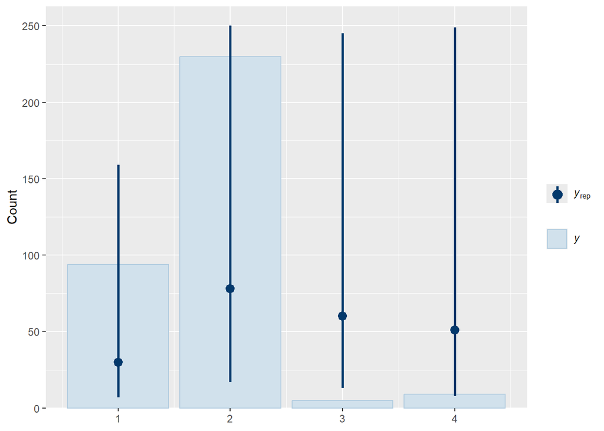

```r
m.prior <-
  brm(data = d, family = categorical(link = logit), formula = f, prior = p,
    iter = 2000, warmup = 1000, chains = 4, cores = 4,
    seed = 4, sample_prior="only",
    file = paste0("../fits/variance.", v, ".prior"), file_refit = "on_change"
  )

brms::pp_check(m.prior, ndraws=100, type = "bars")
```

The prior predictive check confirms the plausibility of the selected prior probability distribution. Given the number of predictors, the weight towards the extreme values is anticipated. Next, we update the coefficient distributions in light of the collected data using Monte Carlo Markov Chain sampling.

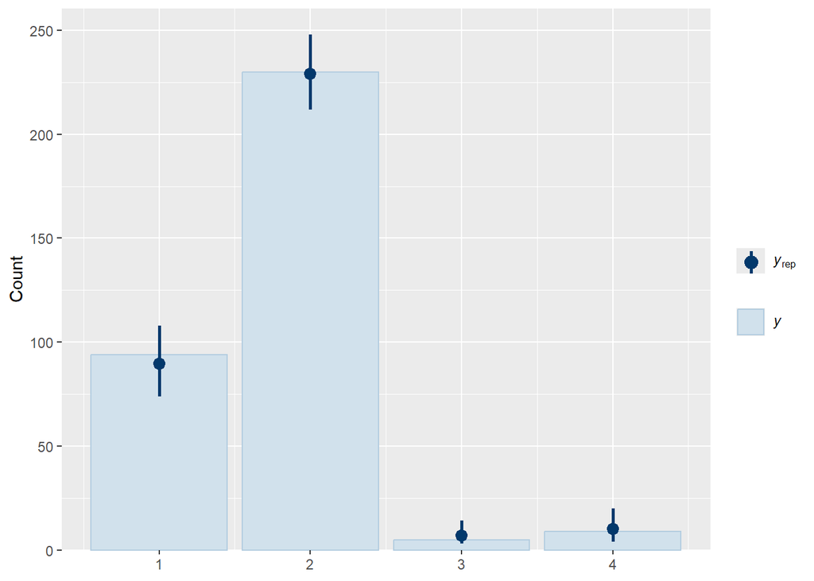

```r
m <-
  brm(data = d, family = categorical(link = logit), formula = f, prior = p,
    iter = 2000, warmup = 1000, chains = 4, cores = 4, seed = 4,
    file = paste0("../fits/variance.", v), file_refit = "on_change"
  )

brms::pp_check(m, ndraws=100, type="bars")
```

The posterior predictive check shows that the model predictions ($y_{rep}$) have grown closer to the actually observed data (`y`). This confirms that the model has trained well.

#### Evaluation

We visualize the marginal effect of each demographic factor on every response option to determine, (1) whether an option can be viewed as “common”, and (2) whether the levels of the demographic factor affect the responses to this question. First, we investigate the effect of the sector (`v_1`) on all response options.

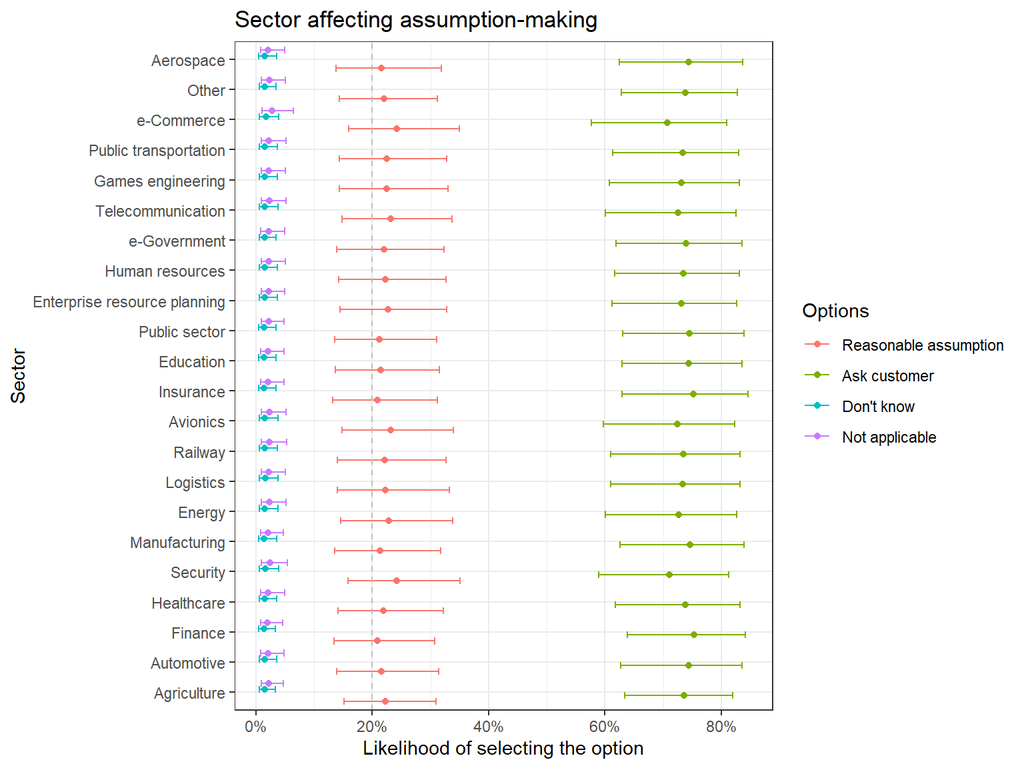

```r
conditional_effects(m, "v_1", categorical = TRUE, prob = 0.89)[[1]] %>%
  mutate(effect2__ = factor(effect2__, ordered = FALSE)) %>%
  ggplot(aes(y = effect1__, color = effect2__)) +
    geom_point(aes(x = estimate__), position = position_dodge(width = 0.8)) +
    geom_errorbar(aes(xmin = lower__, xmax = upper__), position = position_dodge(width = 0.8)) +
    geom_vline(xintercept = level.common, color = "grey", linetype = "dashed") +
    scale_x_continuous(labels = scales::percent) +
    labs(x = "Likelihood of selecting the option", y = "Sector", color = "Options") +
    ggtitle(paste0("Sector affecting ", vname)) +
    theme_bw()
```

The next figure shows the marginal effect of the project size (`v_3`) on the outcomes.

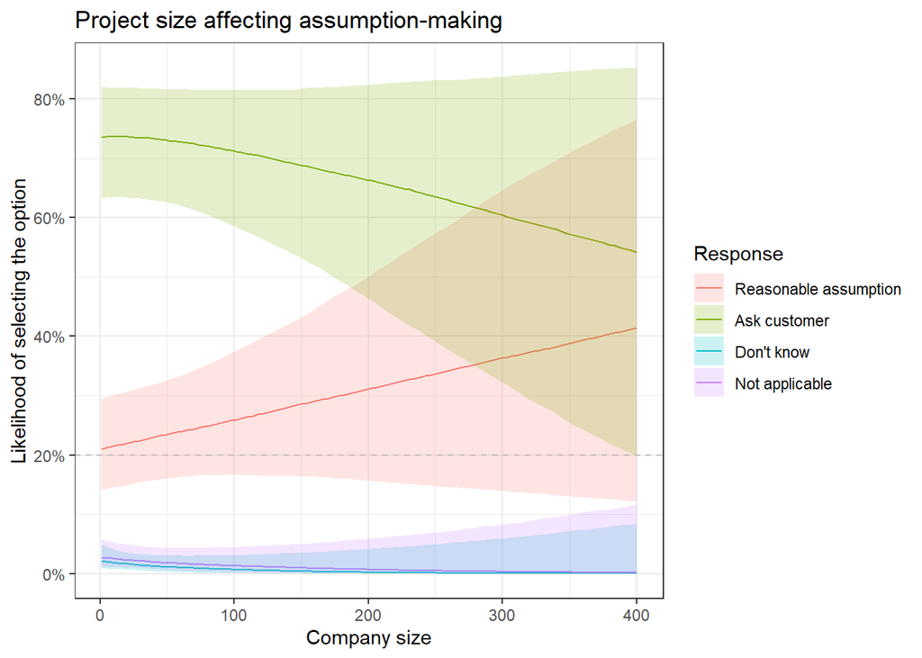

```r
conditional_effects(m, "v_3", categorical = TRUE, prob = 0.89)[[1]] %>%
  mutate(effect2__ = factor(effect2__, ordered = FALSE)) %>%
  ggplot(aes(x = effect1__)) +
    geom_line(aes(y = estimate__, color = effect2__)) +
    geom_ribbon(aes(ymin = lower__, ymax = upper__, fill = effect2__), alpha = 0.2) +
    geom_hline(yintercept = 0.2, color = "grey", linetype = "dashed") +
    labs(x = "Company size", y = "Likelihood of selecting the option",
         color = "Response", fill = "Response") +
    scale_y_continuous(labels = scales::percent) +
    ggtitle(paste0("Project size affecting ", vname)) +
    theme_bw()
```

The following figure shows the marginal effect of the country (`Country`) on the outcomes.

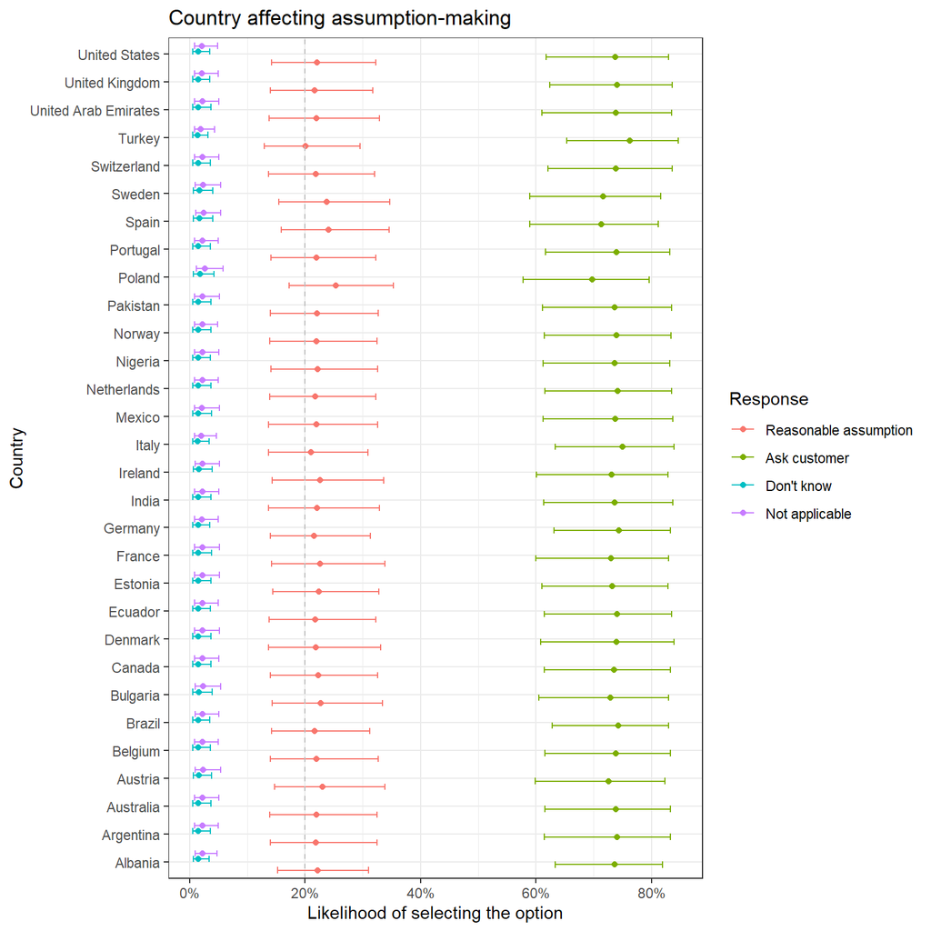

```r
conditional_effects(m, "Country", categorical = TRUE, prob = 0.89)[[1]] %>%
  mutate(effect2__ = factor(effect2__, ordered = FALSE)) %>%
  ggplot(aes(y = effect1__, color = effect2__)) +
    geom_point(aes(x = estimate__), position = position_dodge(width = 0.8)) +
    geom_errorbar(aes(xmin = lower__, xmax = upper__), position = position_dodge(width = 0.8)) +
    geom_vline(xintercept = level.common, color = "grey", linetype = "dashed") +
    scale_x_continuous(labels = scales::percent) +
    labs(x = "Likelihood of selecting the option", y = "Country", color = "Response") +
    ggtitle(paste0("Country affecting ", vname)) +
    theme_bw()
```

The next figure shows the variance induced by the way-of-working (`v_457`).

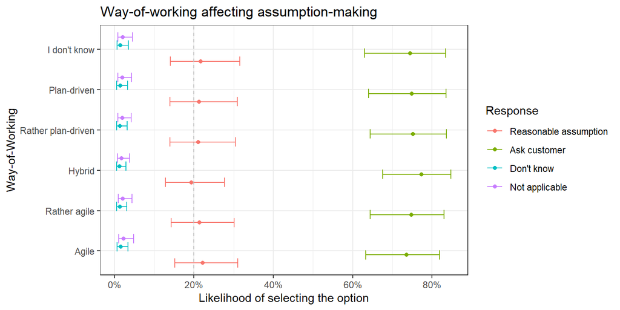

```r
conditional_effects(m, "v_457", categorical = TRUE, prob = 0.89)[[1]] %>%
  mutate(effect2__ = factor(effect2__, ordered = FALSE)) %>%
  ggplot(aes(y = effect1__, color = effect2__)) +
    geom_point(aes(x = estimate__), position = position_dodge(width = 0.8)) +
    geom_errorbar(aes(xmin = lower__, xmax = upper__), position = position_dodge(width = 0.8)) +
    geom_vline(xintercept = level.common, color = "grey", linetype = "dashed") +
    scale_x_continuous(labels = scales::percent) +
    labs(x = "Likelihood of selecting the option", y = "Way-of-Working", color = "Response") +
    ggtitle(paste0("Way-of-working affecting ", vname)) +
    theme_bw()
```

The next figure shows the variance induced by whether or not the project includes external partners (`v_16`).

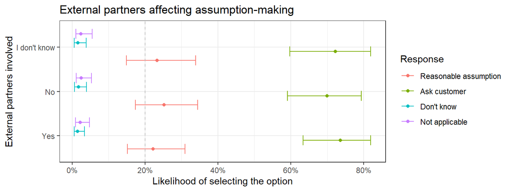

```r
conditional_effects(m, "v_16", categorical = TRUE, prob = 0.89)[[1]] %>%
  mutate(effect2__ = factor(effect2__, ordered = FALSE)) %>%
  ggplot(aes(y = effect1__, color = effect2__)) +
    geom_point(aes(x = estimate__), position = position_dodge(width = 0.8)) +
    geom_errorbar(aes(xmin = lower__, xmax = upper__), position = position_dodge(width = 0.8)) +
    geom_vline(xintercept = level.common, color = "grey", linetype = "dashed") +
    scale_x_continuous(labels = scales::percent) +
    labs(x = "Likelihood of selecting the option", y = "External partners involved", color = "Response") +
    ggtitle(paste0("External partners affecting ", vname)) +
    theme_bw()
```

The next figure shows the variance induced by whether or not the project is distributed (`v_357`).

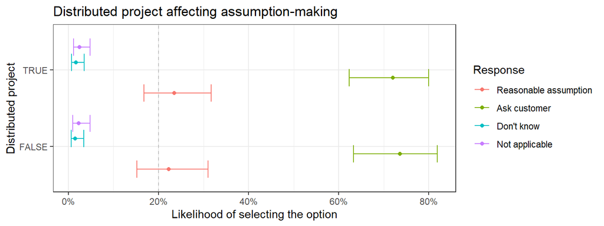

```r
conditional_effects(m, "v_357", categorical = TRUE, prob = 0.89)[[1]] %>%
  mutate(effect2__ = factor(effect2__, ordered = FALSE)) %>%
  ggplot(aes(y = effect1__, color = effect2__)) +
    geom_point(aes(x = estimate__), position = position_dodge(width = 0.8)) +
    geom_errorbar(aes(xmin = lower__, xmax = upper__), position = position_dodge(width = 0.8)) +
    geom_vline(xintercept = level.common, color = "grey", linetype = "dashed") +
    scale_x_continuous(labels = scales::percent) +
    labs(x = "Likelihood of selecting the option", y = "Distributed project", color = "Response") +
    ggtitle(paste0("Distributed project affecting ", vname)) +
    theme_bw()
```

The next figure shows the variance induced by the degree of virtualization (`v_377`).

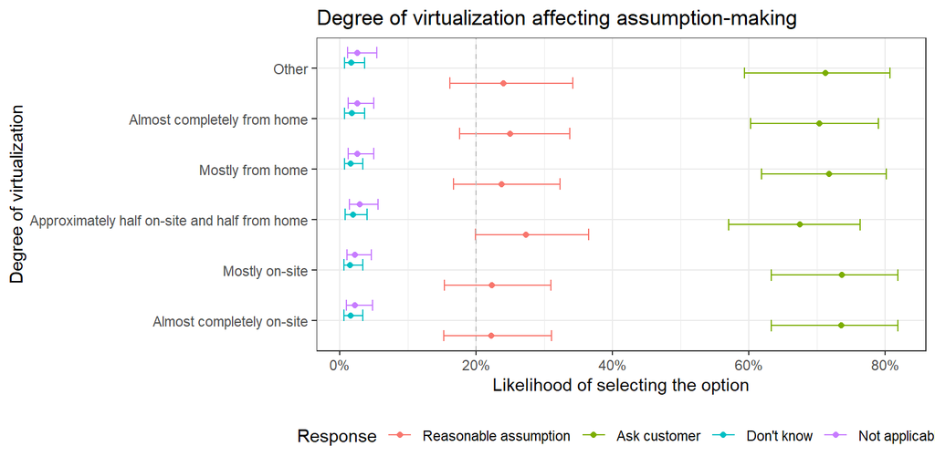

```r
conditional_effects(m, "v_377", categorical = TRUE, prob = 0.89)[[1]] %>%
  mutate(effect2__ = factor(effect2__, ordered = FALSE)) %>%
  ggplot(aes(y = effect1__, color = effect2__)) +
    geom_point(aes(x = estimate__), position = position_dodge(width = 0.8)) +
    geom_errorbar(aes(xmin = lower__, xmax = upper__), position = position_dodge(width = 0.8)) +
    geom_vline(xintercept = level.common, color = "grey", linetype = "dashed") +
    scale_x_continuous(labels = scales::percent) +
    labs(x = "Likelihood of selecting the option", y = "Degree of virtualization", color = "Response") +
    ggtitle(paste0("Degree of virtualization affecting ", vname)) +
    theme_bw() +
    theme(legend.position = "bottom")
```

The final figure shows the variance induced by the main role of the participant (`v_17`).

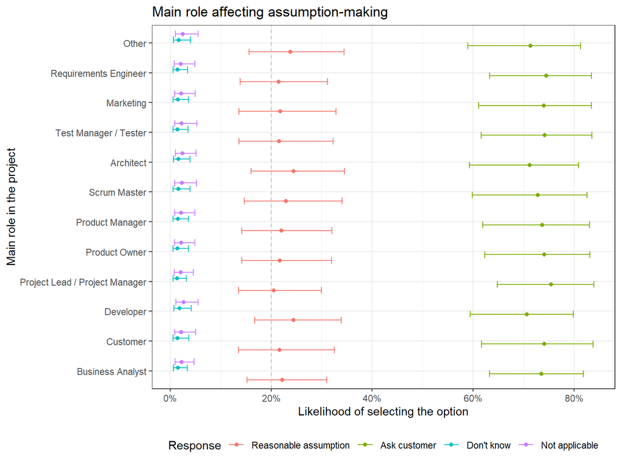

```r
conditional_effects(m, "v_17", categorical = TRUE, prob = 0.89)[[1]] %>%
  mutate(effect2__ = factor(effect2__, ordered = FALSE)) %>%
  ggplot(aes(y = effect1__, color = effect2__)) +
    geom_point(aes(x = estimate__), position = position_dodge(width = 0.8)) +
    geom_errorbar(aes(xmin = lower__, xmax = upper__), position = position_dodge(width = 0.8)) +
    geom_vline(xintercept = level.common, color = "grey", linetype = "dashed") +
    scale_x_continuous(labels = scales::percent) +
    labs(x = "Likelihood of selecting the option", y = "Main role in the project", color = "Response") +
    ggtitle(paste0("Main role affecting ", vname)) +
    theme_bw() +
    theme(legend.position = "bottom")
```

[^1]: McElreath, R. (2018). Statistical rethinking: A Bayesian course with examples in R and Stan. Chapman and Hall/CRC.